# 하루 10분 SQL

## 08장 기본 명령어

### 8.1 SELECT

구문 #1 SELECT * FROM 테이블명;

구문 #2 필드명1, 필드명2 …, 필드명n FROM 테이블명;

예제 #1 고객 테이블의 전체 내용을 검색한다.

- SQL SELECT
  - FROM tb_customer;
- 결과

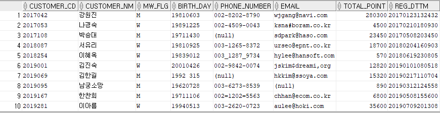

- 설명 SELECT 명령에 ’*’ 문자를 지정해 고객 테이블의 전체 내용을 검색했다. 이SQL은 테이블의 모든 내용을 검색하는 가장 기본적인 명령이다.

예제 #2 고객 테이블에서 고객코드, 고객명, 전화번호, 이메일을 검색한다.

- SQL SELECT customer_cd, customer_nm, phone_number, email FROM tb_customer;
- 결과

[figure not shown]

- 설명 고객 테이블(tb_customer)에서 고객코드(customer_cd), 고객명(customer_nm), 전화번호(phone_number), 이메일(email)을 검색했다. 이 명령은 필드가 많은 테이블에서 필요한 내용만 검색한다.

예제 #3 고객 테이블에서 고객코드, 고객명, 전화번호, 이메일을 검색하면서 필드 제목을 한글로 바꾼다.

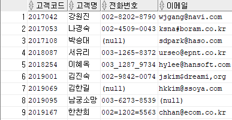

- 설명 고객 테이블(tb_customer)에서 고객코드(customer_cd), 고객명(customer_nm), 전화번호(phone_number), 이메일(email)을 검색하면서 영문 필드명인 customer_cd는 ’고객코드’등으로 바꿨다.

### 8.2 WHERE

구문 #1 SELECT 검색필드명

구문 #2 FROM 테이블명

구문 #3 WHERE 조건식;

예제 #1 고객 테이블에서 남성인 고객을 검색한다.

- SQL SELECT
  - FROM tb_customer WHERE mw_flg = ‘M’;
- 결과

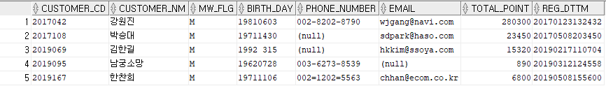

- 설명 고객 테이블(tb_customer)에서 성별(MW_flg)이 남성(‘M’)인 조건으로 검색했다. 성별이 모두 ’M’인지 확인한다. 성별은 ’M’이 남성이고 ’W’는 여성이다.

### 8.3 AND

구문 #1 SELECT 검색필드명

구문 #2 FROM 테이블명

구문 #3 WHERE 조건식1 AND 조건식2 AND … 조건식n;

예제 #1 고객 테이블에서 2019년 이후 등록한 여성 고객을 검색한다.

- SQL SELECT
  - FROM tb_customer WHERE customer_cd > ‘2019000’ and mw_flg = ‘W’;
- 결과

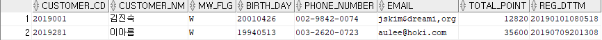

- 설명 고객 테이블(tb_customer)에서 고객코드(customer_cd)가 ‘2019000’보다 크고 성별(MW_flg)이 여성(’W’)인 조건으로 검색했다.

예제 #2 고객 테이블에서 남성이면서 출생 연도가 ’1990’년 미만인 고객을 검색한다.

- SQL SELECT
  - FROM tb_customer WHERE birth_day < ‘19900101’ and mw_flg = ‘M’;
- 결과

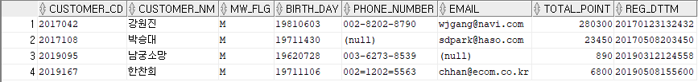

- 설명 고객 테이블(tb_customer)에서 성별(MW_flg)이 남성(‘M’)이고 생년월일(birth_day)이 ‘19900101’ 미만인 조건으로 검색했다.

### 8.4 OR

구문 #1 SELECT 검색필드명

구문 #2 FROM 테이블명

구문 #3 WHERE 조건식1 OR 조건식2 OR … 조건식n;

예제 #1 고객 테이블에서 생년월일이 ‘19900101’ 이후거나 누적포인트가 20,000이상인 고객을 검색한다.

- SQL SELECT
  - FROM tb_customer WHERE birth_day >= ‘19900101’ OR total_point >= 20000;
- 결과

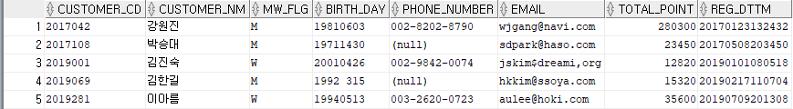

- 설명 고객 테이블(tb_customer)에서 생년월일(birth_day)이 ‘19900101’ 이후거나, 누적포인트(total_point)가 20,000 이상인 조건으로 검색했다.

예제 #2 고객 테이블에서 남성인 고객 중 생년월일이 ‘19700101’ 이전이거나 누적포인트가 20,000 이상인 고객을 검색한다.

- SQL SELECT
  - FROM tb_customer WHERE mw_flg = ‘M’ and (birth_day < ‘19700101’ OR total_point >= 20000);
- 결과

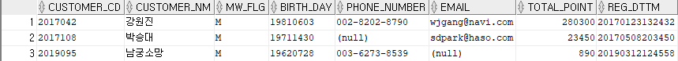

- 설명 고객 테이블(tb_customer)에서 성별(MW_flg)이 남성(‘M’)인 고객 중 생년월일(birth_day)이 ‘19700101’ 이전이거나 누적포인트(total_point)가 20,000 이상인 조건으로 검색했다.

### 8.5 BETWEEN .. AND

구문 #1 SELECT 검색필드명

구문 #2 FROM 테이블명

구문 #3 WHERE 필드명 [NOT] BETWEEN 시작값 AND 종료값;

예제 #1 고객 테이블에서 여성이고 누적포인트가 10,000에서 20,000 이하인 고객을 검색한다.

- SQL SELECT
  - FROM tb_customer WHERE mw_flg = ‘W’ and total_point BETWEEN 10000 AND 20000;
- 결과

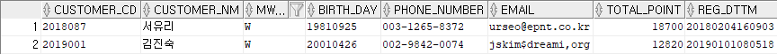

- 설명 고객 테이블(tb_customer)에서 성별(MW_flg)이 여성(‘W’)이고 누적포인트(total_point)가 10,000과 20,000 사이인 고객을 검색했다.

예제 #2 고객 테이블에서 생년월일이 ‘19800101’과 ’19891231’ 사이인 고객을 검색한다.

- SQL SELECT
  - FROM tb_customer WHERE birth_day BETWEEN ‘19800101’ AND ‘19891231’;
- 결과

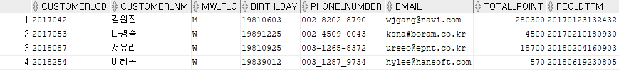

- 설명 고객 테이블(tb_customer)에서 생년월일(birth_day)이 ‘19800101’과 ’19891231’ 사이에 속하는 고객을 검색했다.